```python
import IPython
```

```python
%%javascript
IPython.load_extensions('IPython-notebook-extensions-2.x/slidemode/main');
```

[figure not shown]

# Equations of Electrodynamics: From Maxwell to Helmholtz

### This talk **focuses** on

#### Deriving Helmholtz from Maxwell

#### Numerical/Analytical Solutions of Deterministic Helmholtz

#### Numercial Methods for Stochastic Helmholtz

#### Rates of Convergence

```python
import numpy as np
import pandas as pd
import pandas.io.data as pdd
from urllib import urlretrieve
from IPython.display import HTML, Image
%matplotlib inline
```

$$\newcommand\der[2]{\frac{d{#1}}{d{#2}}} \newcommand\dder[2]{\frac{d^2{#1}}{d{#2}^2}} \newcommand\ddder[2]{\frac{d^3{#1}}{d{#2}^3}} \newcommand\pder[2]{\frac{\partial #1}{\partial #2}} \newcommand\ppder[2]{\frac{\partial^2 #1}{\partial #2^2}} \newcommand\pnder[3]{\frac{\partial^{#3} #1}{\partial #2^{#3}}} \newcommand\der[2]{\frac{d{#1}}{d{#2}}} \newcommand\dder[2]{\frac{d^2{#1}}{d{#2}^2}} \newcommand\ddder[2]{\frac{d^3{#1}}{d{#2}^3}} \newcommand\pder[2]{\frac{\partial #1}{\partial #2}} \newcommand\ppder[2]{\frac{\partial^2 #1}{\partial #2^2}} \newcommand\pnder[3]{\frac{\partial^{#3} #1}{\partial #2^{#3}}} \newcommand\pdder[3]{\frac{\partial^2 #1}{\partial #2 \partial #3}} \newcommand\pddder[4]{\frac{\partial^3 #1}{\partial #2 \partial #3 \partial #4}} \let\truesum=\sum \def\sum{\mathop{\textstyle\truesum}\limits} \def\Re#1{\mathrm{Re}\hspace{-0.03in}\left[#1\right]} \def\Im#1{\mathrm{Im}\hspace{-0.03in}\left[#1\right]} \def\bigOh#1{O\hspace{-0.03in}\left(#1\right)} \def\littelOh#1{o\hspace{-0.03in}\left(#1\right)} \def\conj#1{\bar{#1}} \newcommand{\intl}[4]{\int_{#3}^{#4} #1 \, d #2} \def\Del#1{\Delta(#1)} \def\del#1{\delta\hspace{-0.03in}\left(#1 \right)} \def\Int#1#2{\left[\int #1 \, d#2\right]} \def\iint{\int \int} \def\dmin#1#2{\displaystyle{\min_{#1}}\hspace{-0.03in}\left(#2 \right)} \def\dmax#1#2{\displaystyle{\max_{#1}}\hspace{-0.03in}\left(#2 \right)} \def\dargmin#1#2{\displaystyle{{\mathrm{argmin}}_{#1}}\hspace{-0.03in}\left(#2 \right)} \def\dargmax#1#2{\displaystyle{{\mathrm{argmax}}_{#1}}\hspace{-0.03in}\left(#2 \right)} \def\vect#1{\mathbf{#1}} \def\gvect#1{\boldsymbol{#1}} \def\ip#1#2{\left \langle #1,#2 \right \rangle} \def\Ip#1#2{\Re{\int \conj{#1}\, #2 \,dt}} \def\adjoint#1{#1^{\dagger}} \require{cancel}$$

##### Maxwell's system in differential form:

[output not shown]

##### Definitions:

| Symbol | Meaning | SI unit of measure |
| --- | --- | --- |
| $$\vect{E}$$ | electric field | $$V/m$$ |
| $$\vect{P}$$ | electric polarization | $$N/ (Vm)$$ |
| $$\vect{D}$$ | electric displacement | $$N/(Vm)$$ |
| $$\vect{B}$$ | magnetic field | $$V s/m^2$$ |
| $$\vect{M}$$ | magnetization | $$A/m$$ |
| $$\vect{H}$$ | magnetic displacement | $$A/m$$ |
| $$\vect{J}_f$$ | current density | $$C/(s m^2)$$ |
| $$\vect{K}_f$$ | current surface density | $$C/ s m$$ |
| $$\rho_f$$ | charge density | $$C/ m^3$$ |
| $$\sigma_f$$ | surface charge density | $$C/ m^2$$ |
| $\epsilon_0 \approx 8.8 \times 10^{-12}$ | permitting of free space | $$C^2/(Nm^2)$$ |
| $$\mu_0 \approx 4\pi \times 10^{-7}$$ | permeability of free space | $$V s / (A m) $$ |
| $$c \approx 2.9 \times 10^{-8}$$ | speed of light in vac | $$m/s$$ |

##### Using the Constitutive Relations and taking **dot** products...

\begin{equation} \vect{E} \cdot \left(\nabla \times \frac{1}{\mu_0} \vect{B}\right) - \frac{1}{\mu_0} \vect{B} \cdot \left(\nabla \times \vect{E}\right) = \vect{E} \cdot \left(\nabla \times \vect{M}\right) + \vect{E} \cdot \vect{J}_f + \vect{E} \cdot \pder{\epsilon_0 \vect{E}}{t} + \vect{E} \cdot\pder{\vect{P}}{t} + \frac{1}{\mu_0} \vect{B} \pder{\vect{B}}{t} \end{equation}

##### or

\begin{equation} \pder{}{t}\left(\frac{\epsilon_0}{2} \vect{E} \cdot \vect{E} + \frac{1}{2\mu_0}\vect{B}\cdot\vect{B}\right) = -\nabla \cdot \left(\vect{E} \times \frac{1}{\mu_0} \vect{B}\right) - \vect{E} \cdot \left( \vect{J}_f + \pder{\vect{P}}{t} + \left(\nabla \times \vect{M}\right)\right) \end{equation}

##### produces conservation (energy density) equation!

##### Using the Constitutive Relations and taking **cross** products...

\begin{equation} \begin{split} \epsilon_0 \nabla \cdot \vect{E} +\nabla \cdot \vect{P} &= \rho_f \\ \nabla \times \nabla \times \vect{E} & = - \mu_0\pder{\vect{J}_f}{t} - \mu_0\pder{\left(\nabla \times \vect{M}\right)}{t} - \mu_0 \epsilon_0 \ppder{\vect{E}}{t} -\mu_0\ppder{\vect{P}}{t}\\ \nabla \cdot \vect{B} &= 0 \\ \nabla \times \nabla \times \vect{B} &= \mu_0\nabla \times \nabla \times \vect{M} + \mu_0 \nabla \times \vect{J}_f - \mu_0 \epsilon\ppder{\vect{B}}{t} +\mu_0 \pder{\left(\nabla \times\vect{P}\right)}{t} \end{split} \end{equation}

##### and using $\nabla \times \nabla \times\vect{A} = -\nabla^2\vect{A} + \nabla (\nabla \cdot \vect{A})$...

\begin{equation} \begin{split} \nabla \cdot \vect{E} &= \frac{\rho_f}{\epsilon_0} - \frac{1}{\epsilon_0} \nabla \cdot \vect{P} \\ \nabla^2 \vect{E} - \mu_0 \epsilon_0 \ppder{\vect{E}}{t} &= \mu_0\pder{\vect{J}_f}{t} + \mu_0\pder{\left(\nabla \times \vect{M}\right)}{t} + \frac{\nabla \rho_f}{\epsilon_0} - \frac{1}{\epsilon_0} \nabla \left(\nabla \cdot \vect{P} \right) + \mu_0\ppder{\vect{P}}{t}\\ \nabla \cdot \vect{B} &= 0 \\ \nabla^2\vect{B} - \mu_0 \epsilon_0 \ppder{\vect{B}}{t} &= -\mu_0\nabla \times \nabla \times \vect{M} - \mu_0 \nabla \times \vect{J}_f - \mu_0 \pder{\left(\nabla \times\vect{P}\right)}{t} \end{split} \end{equation}

##### Lets make some assumptions...

- Non-magnetic medium with no free charge: $ \rho_f = 0$, $\vect{J}_f = \vect{0}$, $\vect{M} = \vect{0}$

\begin{equation} \begin{split} \nabla \cdot \vect{E} &= \xcancel{\frac{\rho_f}{\epsilon_0}} - \frac{1}{\epsilon_0} \nabla \cdot \vect{P} \\ \nabla^2 \vect{E} - \mu_0 \epsilon_0 \ppder{\vect{E}}{t} &= \xcancel{\mu_0\pder{\vect{J}_f}{t}} + \xcancel{\mu_0\pder{\left(\nabla \times \vect{M}\right)}{t}} + \xcancel{\frac{\nabla \rho_f}{\epsilon_0}} - \frac{1}{\epsilon_0} \nabla \left(\nabla \cdot \vect{P} \right) + \mu_0\ppder{\vect{P}}{t}\\ \nabla \cdot \vect{B} &= 0 \\ \nabla^2\vect{B} - \mu_0 \epsilon_0 \ppder{\vect{B}}{t} &= \xcancel{-\mu_0 \nabla \times \nabla \times \vect{M}} - \xcancel{\mu_0 \nabla \times \vect{J}_f} - \mu_0 \pder{\left(\nabla \times\vect{P}\right)}{t} \end{split} \end{equation}

##### Lets make some assumptions...

- Non-magnetic medium with no free charge: $ \rho_f = 0$, $\vect{J}_f = \vect{0}$, $\vect{M} = \vect{0}$
- Instantious and isotropic polarization: $\vect{P}(\vect{E}) = \epsilon_0 \chi(\vect{r},t) \vect{E}$

  \begin{equation} \begin{split} \nabla \cdot \vect{E} &= -\chi\nabla \cdot \vect{E} - \vect{ \nabla\chi} \cdot \vect{E} \\ \nabla^2 \vect{E} - \frac{1}{c^2} \ppder{\vect{E}}{t} &= - \nabla \left(\nabla \cdot \chi \vect{E} \right) + \frac{1}{c^2} \ppder{ \chi \vect{E}}{t}\\ \nabla \cdot \vect{B} &= 0 \\ \nabla^2\vect{B} - \frac{1}{c^2}\ppder{\vect{B}}{t} &= -\frac{1}{c^2} \pder{\left(\nabla \times \chi \vect{E}\right)}{t} \end{split} \end{equation}

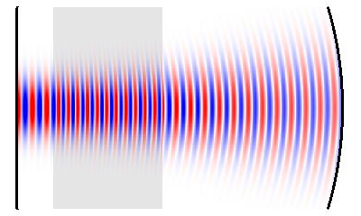

```python
Image('http://www.rp-photonics.com/img/resonator_mode_2.png')
#Image('images/resonator_mode_2.png')
```

### Exercise

Trend-based investment strategy with the EURO STOXX 50 index:

- 2 trends 42d & 252d
- long, short, cash positions
- no transaction costs

Signal generation:

- invest (go long) when the 42d trend is more than 100 points above the 252d trend
- sell (go short) when the 42d trend is more than 20 points below the 252d trend
- invest in cash (no interest) when neither of both is true

## Historical Correlation between EURO STOXX 50 and VSTOXX

It is a stylized fact that stock indexes and related volatility indexes are **highly negatively correlated**. The following example analyzes this stylized fact based on the EURO STOXX 50 stock index and the VSTOXX volatility index using Ordinary Least-Squares regession (OLS).

First, we collect historical data for both the EURO STOXX 50 stock and the VSTOXX volatility index.

```python
import pandas as pd
import datetime as dt
from urllib import urlretrieve
```

```python
try:
    es_url = 'http://www.stoxx.com/download/historical_values/hbrbcpe.txt'
    vs_url = 'http://www.stoxx.com/download/historical_values/h_vstoxx.txt'
    urlretrieve(es_url, 'es.txt')
    urlretrieve(vs_url, 'vs.txt')
except:
    pass
```

The **EURO STOXX 50 data** is not yet in the right format. Some house cleaning is necessary (I).

```python
lines = open('es.txt').readlines()  # reads the whole file line-by-line
```

```python
lines[:5]  # header not well formatted
```

```
['Price Indices - EURO Currency\n',
 'Date    ;Blue-Chip;Blue-Chip;Broad    ; Broad   ;Ex UK    ;Ex Euro Zone;Blue-Chip; Broad\n',
 '        ;  Europe ;Euro-Zone;Europe   ;Euro-Zone;         ;            ; Nordic  ; Nordic\n',
 '        ;  SX5P   ;  SX5E   ;SXXP     ;SXXE     ; SXXF    ;    SXXA    ;    DK5F ; DKXF\n',
 '31.12.1986;775.00 ;  900.82 ;   82.76 ;   98.58 ;   98.06 ;   69.06 ;  645.26  ;  65.56\n']
```

The **EURO STOXX 50 data** is not yet in the right format. Some house cleaning is necessary (II).

```python
lines[3883:3890]  # from 27.12.2001 additional semi-colon
```

```
['20.12.2001;3537.34;  3617.47;   286.07;   300.97;   317.10;   267.23;  5268.36 ;  363.19\n',
 '21.12.2001;3616.80;  3696.44;   291.39;   306.60;   322.55;   272.18;  5360.52 ;  370.94\n',
 '24.12.2001;3622.85;  3696.98;   291.90;   306.77;   322.69;   272.95;  5360.52 ;  370.94\n',
 '27.12.2001;3686.23;  3778.39;   297.11;   312.43;   327.57;   277.68;  5479.59;   378.69;\n',
 '28.12.2001;3706.93;  3806.13;   298.73;   314.52;   329.94;   278.87;  5585.35;   386.99;\n',
 '02.01.2002;3627.81;  3755.56;   293.69;   311.43;   326.77;   272.38;  5522.25;   380.09;\n',
 '03.01.2002;3699.09;  3833.09;   299.09;   317.54;   332.62;   277.08;  5722.57;   396.12;\n']
```

The **EURO STOXX 50 data** is not yet in the right format. Some house cleaning is necessary (III).

```python
lines = open('es.txt').readlines()  # reads the whole file line-by-line
new_file = open('es50.txt', 'w')  # opens a new file
new_file.writelines('date' + lines[3][:-1].replace(' ', '') + ';DEL' + lines[3][-1])
    # writes the corrected third line (additional column name)
    # of the orginal file as first line of new file
new_file.writelines(lines[4:])  # writes the remaining lines of the orginal file
```

The **EURO STOXX 50 data** is not yet in the right format. Some house cleaning is necessary (IV).

```python
list(open('es50.txt'))[:5]  # opens the new file for inspection
```

```
['date;SX5P;SX5E;SXXP;SXXE;SXXF;SXXA;DK5F;DKXF;DEL\n',
 '31.12.1986;775.00 ;  900.82 ;   82.76 ;   98.58 ;   98.06 ;   69.06 ;  645.26  ;  65.56\n',
 '01.01.1987;775.00 ;  900.82 ;   82.76 ;   98.58 ;   98.06 ;   69.06 ;  645.26  ;  65.56\n',
 '02.01.1987;770.89 ;  891.78 ;   82.57 ;   97.80 ;   97.43 ;   69.37 ;  647.62  ;  65.81\n',
 '05.01.1987;771.89 ;  898.33 ;   82.82 ;   98.60 ;   98.19 ;   69.16 ;  649.94  ;  65.82\n']
```

Now, the data can be safely read into a DataFrame object.

```python
es = pd.read_csv('es50.txt', index_col=0, parse_dates=True, sep=';', dayfirst=True)
```

```python
del es['DEL']  # delete the helper column
```

```python
es.info()
```

```
<class 'pandas.core.frame.DataFrame'>
DatetimeIndex: 6997 entries, 1986-12-31 00:00:00 to 2014-02-18 00:00:00
Data columns (total 8 columns):
SX5P    6997 non-null float64
SX5E    6997 non-null float64
SXXP    6997 non-null float64
SXXE    6997 non-null object
SXXF    6996 non-null float64
SXXA    6996 non-null float64
DK5F    6996 non-null float64
DKXF    6996 non-null float64
dtypes: float64(7), object(1)
```

The VSTOXX data can be read without touching the raw data.

```python
vs = pd.read_csv('vs.txt', index_col=0, header=2, parse_dates=True, sep=',', dayfirst=True)

# you can alternatively read from the Web source directly
# without saving the csv file to disk:
# vs = pd.read_csv(vs_url, index_col=0, header=2,
#                  parse_dates=True, sep=',', dayfirst=True)
```

We now **merge the data** for further analysis.

```python
import datetime as dt
data = pd.DataFrame({'EUROSTOXX' :
            es['SX5E'][es.index > dt.datetime(1999, 12, 31)]})
data = data.join(pd.DataFrame({'VSTOXX' :
            vs['V2TX'][vs.index > dt.datetime(1999, 12, 31)]}))
data.info()
```

```
<class 'pandas.core.frame.DataFrame'>
DatetimeIndex: 3622 entries, 2000-01-03 00:00:00 to 2014-02-18 00:00:00
Data columns (total 2 columns):
EUROSTOXX    3622 non-null float64
VSTOXX       3600 non-null float64
dtypes: float64(2)
```

Let's inspect the two time series.

```python
data.head()
```

| date | EUROSTOXX | VSTOXX |
| --- | --- | --- |
| 2000-01-03 | 4849.22 | 30.9845 |
| 2000-01-04 | 4657.83 | 33.2225 |
| 2000-01-05 | 4541.75 | 32.5944 |
| 2000-01-06 | 4500.69 | 31.1811 |
| 2000-01-07 | 4648.27 | 27.4407 |

5 rows × 2 columns

A **picture** can tell almost the complete story.

```
array([<matplotlib.axes.AxesSubplot object at 0x108087d90>,
       <matplotlib.axes.AxesSubplot object at 0x107517850>], dtype=object)
```

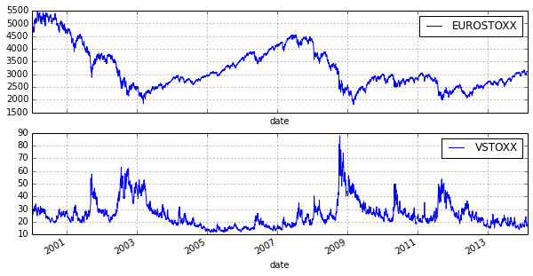

```python
data.plot(subplots=True, grid=True, style='b', figsize=(10, 5))
```

We now generate **log returns** for both time series.

```python
rets = np.log(data / data.shift(1))
rets.head()
```

| date | EUROSTOXX | VSTOXX |
| --- | --- | --- |
| 2000-01-03 | NaN | NaN |
| 2000-01-04 | -0.040268 | 0.069740 |
| 2000-01-05 | -0.025237 | -0.019087 |
| 2000-01-06 | -0.009082 | -0.044328 |
| 2000-01-07 | 0.032264 | -0.127785 |

5 rows × 2 columns

To this new data set, also stored in a DataFrame object, we apply **OLS**.

```python
xdat = rets['EUROSTOXX']
ydat = rets['VSTOXX']
model = pd.ols(y=ydat, x=xdat)
model
```

```
-------------------------Summary of Regression Analysis-------------------------

Formula: Y ~ <x> + <intercept>

Number of Observations:         3577
Number of Degrees of Freedom:   2

R-squared:         0.5544
Adj R-squared:     0.5543

Rmse:              0.0379

F-stat (1, 3575):  4447.8744, p-value:     0.0000

Degrees of Freedom: model 1, resid 3575

-----------------------Summary of Estimated Coefficients------------------------
      Variable       Coef    Std Err     t-stat    p-value    CI 2.5%   CI 97.5%
--------------------------------------------------------------------------------
             x    -2.7183     0.0408     -66.69     0.0000    -2.7982    -2.6384
     intercept    -0.0007     0.0006      -1.10     0.2704    -0.0019     0.0005
---------------------------------End of Summary---------------------------------
```

Again, we want to see how our results look graphically.

```
(-0.10000000000000001, 0.16, -0.43562265909764758, 0.43687964474802654)
```

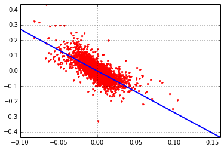

```python
import matplotlib.pyplot as plt
plt.plot(xdat, ydat, 'r.')
ax = plt.axis()  # grab axis values
x = np.linspace(ax[0], ax[1] + 0.01)
plt.plot(x, model.beta[1] + model.beta[0] * x, 'b', lw=2)
plt.grid(True)
plt.axis('tight')
```

Let us see if we can identify **systematics over time**. And indeed, during the crisis 2007/2008 (yellow dots) volatility has been more pronounced than more recently (red dots).

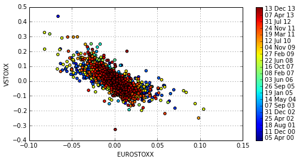

```python
import matplotlib as mpl
mpl_dates = mpl.dates.date2num(rets.index)
plt.figure(figsize=(8, 4))
plt.scatter(rets['EUROSTOXX'], rets['VSTOXX'], c=mpl_dates, marker='o')
plt.grid(True)
plt.xlabel('EUROSTOXX')
plt.ylabel('VSTOXX')
plt.colorbar(ticks=mpl.dates.DayLocator(interval=250),
          format=mpl.dates.DateFormatter('%d %b %y'))
```

### Exercise

We want to test whether the EURO STOXX 50 and/or the VSTOXX returns are **normally distributed** or not (e.g. if they might have fat tails). We want to do a

- graphical illustration (using **qqplot** of **statsmodels.api**) and a
- statistical test (using **normaltest** of **scipy.stats**)

Add on: plot a histogram of the log return frequencies and compare that to a normal distribution with same mean and variance (using e.g. **norm.pdf** from **scipy.stats**)

## Constant Proportion VSTOXX Investment

There has been a number of studies which have illustrated that **constant proportion investments in volatility derivatives** – given a diversified equity portfolio – might improve investment performance considerably. See, for instance, the study

[The Benefits of Volatility Derivatives in Equity Portfolio Management](http://www.eurexgroup.com/group-en/newsroom/60036/)

We now want to replicate (in a simplified fashion) what you can flexibly test here on the basis of two backtesting applications for **VSTOXX-based investment strategies**:

[Two Assets Backtesting](http://www.eurexchange.com/vstoxx/app1/)

[Four Assets Backtesting](http://www.eurexchange.com/vstoxx/app2/)

The strategy we are going to implement and test is characterized as follows:

- An investor has total wealth of say 100,000 EUR
- He invests, say, 70% of that into a diversified equity portfolio
- The remainder, i.e. 30%, is invested in the VSTOXX index directly
- Through (daily) trading the investor keeps the proportions constant
- No transaction costs apply, all assets are infinitely divisible

We already have the necessary data available. However, we want to drop 'NaN' values and want to **normalize the index values**.

```python
data = data.dropna()
```

```python
data = data / data.ix[0] * 100
```

```python
data.head()
```

| date | EUROSTOXX | VSTOXX |
| --- | --- | --- |
| 2000-01-03 | 100.000000 | 100.000000 |
| 2000-01-04 | 96.053180 | 107.222966 |
| 2000-01-05 | 93.659393 | 105.195824 |
| 2000-01-06 | 92.812659 | 100.634511 |
| 2000-01-07 | 95.856035 | 88.562668 |

5 rows × 2 columns

First, the **initial invest**.

```python
invest = 100
cratio = 0.3
data['Equity'] = (1 - cratio) * invest / data['EUROSTOXX'][0]
data['Volatility'] = cratio * invest / data['VSTOXX'][0]
```

This can already be considered an **static** investment strategy.

```python
data['Static'] = (data['Equity'] * data['EUROSTOXX']
                + data['Volatility'] * data['VSTOXX'])
```

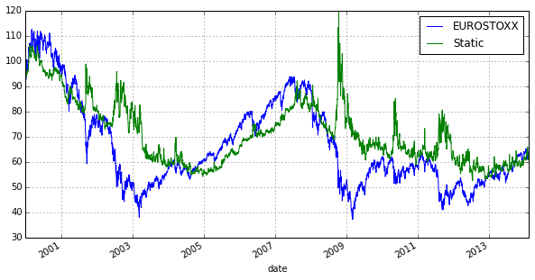

```python
data[['EUROSTOXX', 'Static']].plot(figsize=(10, 5))
```

Second, the dynamic strategy with **daily adjustments** to keep the value ratio constant.

```python
for i in range(1, len(data)):
    evalue = data['Equity'][i - 1] * data['EUROSTOXX'][i]
      # value of equity position
    vvalue = data['Volatility'][i - 1] * data['VSTOXX'][i]
      # value of volatility position
    tvalue = evalue + vvalue
      # total wealth
    data['Equity'][i] = (1 - cratio) * tvalue / data['EUROSTOXX'][i]
      # re-allocation of total wealth to equity ...
    data['Volatility'][i] = cratio * tvalue / data['VSTOXX'][i]
      # ... and volatility position
```

Third, the **total wealth position**.

```python
data['Dynamic'] = (data['Equity'] * data['EUROSTOXX']
                + data['Volatility'] * data['VSTOXX'])
```

```python
data.head()
```

| date | EUROSTOXX | VSTOXX | Equity | Volatility | Static | Dynamic |
| --- | --- | --- | --- | --- | --- | --- |
| 2000-01-03 | 100.000000 | 100.000000 | 0.700000 | 0.300000 | 100.000000 | 100.000000 |
| 2000-01-04 | 96.053180 | 107.222966 | 0.724420 | 0.278124 | 99.404116 | 99.404116 |
| 2000-01-05 | 93.659393 | 105.195824 | 0.725761 | 0.276930 | 97.120322 | 97.106211 |
| 2000-01-06 | 92.812659 | 100.634511 | 0.718221 | 0.283884 | 95.159214 | 95.228521 |
| 2000-01-07 | 95.856035 | 88.562668 | 0.686354 | 0.318376 | 93.668025 | 93.987330 |

5 rows × 6 columns

A brief check if the **ratios are indeed constant**.

```python
(data['Volatility'] * data['VSTOXX'] / data['Dynamic'])[:5]
```

```
date
2000-01-03    0.3
2000-01-04    0.3
2000-01-05    0.3
2000-01-06    0.3
2000-01-07    0.3
dtype: float64
```

```python
(data['Equity'] * data['EUROSTOXX'] / data['Dynamic'])[:5]
```

```
date
2000-01-03    0.7
2000-01-04    0.7
2000-01-05    0.7
2000-01-06    0.7
2000-01-07    0.7
dtype: float64
```

Let us inspect the performance of the strategy.

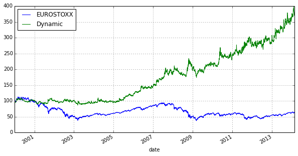

```python
data[['EUROSTOXX', 'Dynamic']].plot(figsize=(10, 5))
```

### Exercise

Write a Python function which allows for an **arbitrary but constant ratio** to be invested in the VSTOXX index and which returns net performance values (in percent) for the constant proportion VSTOXX strategy.

Add on: find the ratio to be invested in the VSTOXX that gives the maximum performance.

## Analyzing High Frequency Data

Using standard Python functionality and pandas, the code that follows reads **intraday, high-frequency data** from a Web source, plots it and resamples it.

```python
try:
    url = 'http://hopey.netfonds.no/posdump.php?'
    url += 'date=%s%s%s&paper=AAPL.O&csv_format=csv' % ('2014', '03', '12')
    # you may have to adjust the date since only recent dates are available
    urlretrieve(url, 'aapl.csv')
except:
    pass
```

```python
AAPL = pd.read_csv('aapl.csv', index_col=0, header=0, parse_dates=True)
```

```python
AAPL.info()
```

```
<class 'pandas.core.frame.DataFrame'>
DatetimeIndex: 9637 entries, 2014-03-12 09:00:01 to 2014-03-12 19:21:50
Data columns (total 6 columns):
bid                  9637 non-null float64
bid_depth            9637 non-null int64
bid_depth_total      9637 non-null int64
offer                9637 non-null float64
offer_depth          9637 non-null int64
offer_depth_total    9637 non-null int64
dtypes: float64(2), int64(4)
```

The **intraday evolution** of the Apple stock price.

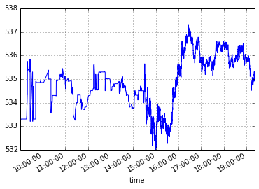

```python
AAPL['bid'].plot()
```

```python
AAPL = AAPL[AAPL.index > dt.datetime(2014, 3, 12, 10, 0, 0)]
  # only data later than 10am at that day
```

A **resampling of the data** is easily accomplished with pandas.

```python
# this resamples the record frequency to 5 minutes, using mean as aggregation rule
AAPL_5min = AAPL.resample(rule='5min', how='mean').fillna(method='ffill')
AAPL_5min.head()
```

| time | bid | bid_depth | bid_depth_total | offer | offer_depth | offer_depth_total |
| --- | --- | --- | --- | --- | --- | --- |
| 2014-03-12 10:00:00 | 534.850000 | 100.000000 | 100.000000 | 536.086000 | 100.000000 | 100.000000 |
| 2014-03-12 10:05:00 | 534.850000 | 100.000000 | 100.000000 | 536.086000 | 100.000000 | 100.000000 |
| 2014-03-12 10:10:00 | 535.355000 | 100.000000 | 100.000000 | 536.090000 | 100.000000 | 100.000000 |
| 2014-03-12 10:15:00 | 535.054286 | 100.000000 | 100.000000 | 536.090000 | 142.857143 | 142.857143 |
| 2014-03-12 10:20:00 | 534.600000 | 133.333333 | 133.333333 | 536.023333 | 116.666667 | 116.666667 |

5 rows × 6 columns

Let's have a graphical look at the new data set.

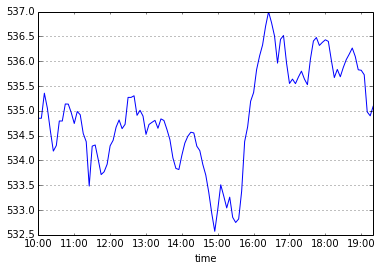

```python
AAPL_5min['bid'].plot()
```

With pandas you can easily apply **custom functions** to time series data.

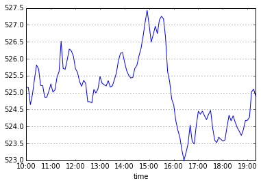

```python
AAPL_5min['bid'].apply(lambda x: 2 * 530 - x).plot()
  # this mirrors the stock price development at
```

## Why Python for Financial Analytics & Visualization?

10 years ago, Python was considered **exotic** in the analytics space – at best. Languages/packages like R and Matlab dominated the scene. Today, Python has become a **major force in financial analytics & visualization** due to a number of characteristics:

- **syntax**: Python syntax is pretty close to the symbolic language used in mathematical finance (also: symbolic Python with SymPy)
- **multi-purpose**: prototyping, development, production, sytems administration – Python is one for all
- **libraries**: there is a library for almost any task or problem you face
- **efficiency**: Python speeds up all IT development tasks for analytics applications and reduces maintenance costs
- **performance**: Python has evolved from a scripting language to a 'meta' language with bridges to all high performance environments (e.g. LLVM, multi-core CPUs, GPUs, clusters)
- **interoperalbility**: Python seamlessly integrates with almost any other language and technology
- **interactivity**: Python allows domain experts to get closer to their business and financial data pools and to do real-time analytics
- **collaboration**: solutions like Wakari with IPython Notebook allow the easy sharing of code, data, results, graphics, etc.

[figure not shown]

## Continuum Analytics Europe GmbH – Python Data Exploration & Visualization

**Continuum Analytics Inc.** – the company Web site

www.continuum.io

**Dr. Yves J. Hilpisch** – my personal Web site

www.hilpisch.com

**Python for Finance** – my NEW book (out as Early Release)

[Python for Finance (O'Reilly)](http://shop.oreilly.com/product/0636920032441.do)

**Derivatives Analytics with Python** – my current book

www.derivatives-analytics-with-python.com

**Contact Us**

yves@continuum.io | europe@continuum.io | [@dyjh](http://twitter.com/dyjh) | [@ContinuumIO](http://twitter.com/ContinuumIO)